# Welcome!

In this notebook, we will be using python and machine learning to solve sudoku puzzles! This is a pretty well-covered, topic, so I won't go into great detail, but instead provide overview of each step of the process and how it all comes together!

## The Goal

The goal of this model is to be able to take a picture of a sudoku puzzle, say from a newpaper, and have the model find the puzzle within the picture, and solve it.

## The Steps

With any project, I believe it is crucial to identify the steps needed in order the reach the project's goal. First, break down the goal into the main steps, and then work your way down from there.

In this case, our main goal can be achieved in 3 main steps:

1. Locate the puzzle within the image
2. Extract the digits within the puzzle
3. Solve and output the puzzle

Sounds easy enough, right? Let's dive right in.

### Step One: Locate the puzzle within the Image

To begin, we'll need to isolate the actual sudoku puzzle from the rest of the image. We can use computer vision algorithms to achieve this, such as OpenCV.

Let's first take a look at the raw image that we'll be working with throughout this example.

```python
import os
import cv2
import matplotlib.pyplot as plt
```

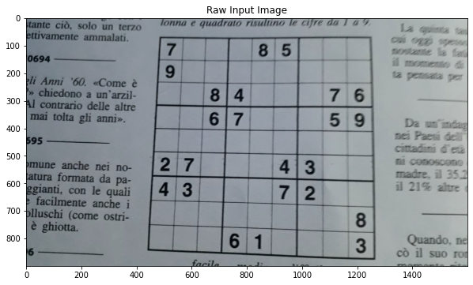

```python
file_list = []

for _file in os.listdir("data/puzzle_imgs/"):
    file_list.append(_file)

puzzle = cv2.imread("data/puzzle_imgs/" + file_list[2])

plt.figure(figsize = (10, 10))
plt.imshow(puzzle)
plt.title("Raw Input Image")
plt.show()
```

Great, now we have an idea of the sort of image we are working with. We can now apply some OpenCV techniques to identify the puzzle itself.

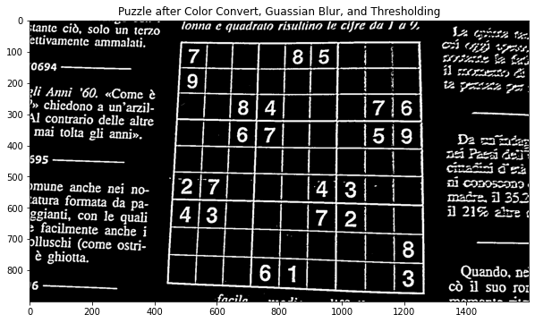

```python
from src.read_puzzle import pre_process_img, find_puzzle_bounds, crop_and_warp, remove_extra

# function to convert image to greyscale and apply thresholding to identify key image components
pre_processed_puzzle = pre_process_img(puzzle)

plt.figure(figsize = (10, 10))
plt.imshow(pre_processed_puzzle, cmap = "gray")
plt.title("Puzzle after Color Convert, Guassian Blur, and Thresholding")
plt.show()
```

```python
# finds the 4 corners of the largest contour in the image (in this case, the puzzle)
puzzle_bounds = find_puzzle_bounds(pre_processed_puzzle)

print(puzzle_bounds)
```

```
[array([485,  67], dtype=int32), array([1253,   67], dtype=int32), array([1265,  876], dtype=int32), array([440, 842], dtype=int32)]
```

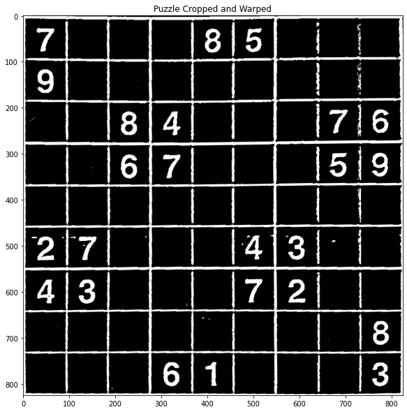

```python
# applies a transformation on the pre-processed image using the bounds from above
# to create a top-down view of the puzzle
cropped_puzzle = crop_and_warp(pre_processed_puzzle, puzzle_bounds)

plt.figure(figsize = (10, 10))
plt.imshow(cropped_puzzle, cmap = "gray")
plt.title("Puzzle Cropped and Warped")
plt.show()
```

### Step Two: Extract the Digits

Now that our puzzle has been located and isolated from the rest of the image, it is time to move onward to the second step of the process - digit extraction. This is a two-fold step.

First, we'll need to slice up our preprocessed image into sections that only contain one number.

Then, we'll feed those sections into a neural network that will classify the number in the image. This is done to transfer the information from the puzzle to a more workable format, such as an array.

```python
def grid_slice(grid, i, j, width):
    """
    Returns a single section of the image based on its coordinates
    """

    i_start = i * width
    i_end = i_start + width

    j_start = j * width
    j_end = j_start + width

    section = grid[i_start:i_end, j_start:j_end]

    return section
```

Let's take a quick look at the results of our slicing function before moving onto the next step.

```python
w, h = cropped_puzzle.shape

width = w // 9 # get width of each digit "section"
```

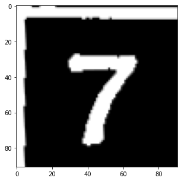

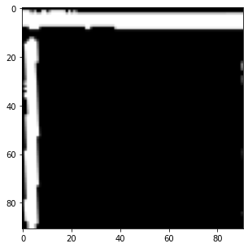

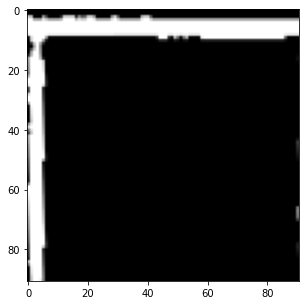

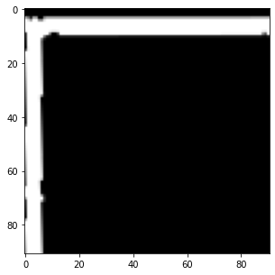

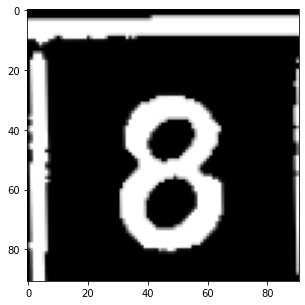

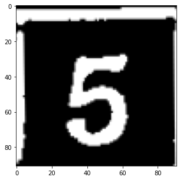

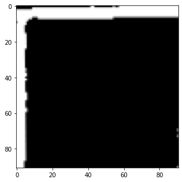

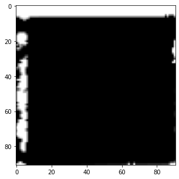

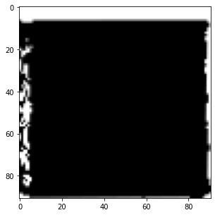

```python
# print the first row of the puzzle as individual sections
for i in range(1):

    for j in range(9):

        digit_section = grid_slice(cropped_puzzle, i, j, width)

        plt.figure(figsize = (5, 5))
        plt.imshow(digit_section, cmap = "gray")
```

Great, that's working as expected! However, we can see that our section slicing is far from perfect, and many images contain a great deal of the "border" between sections. This could throw off our digit recognition step, so we want to remove that as best we can.

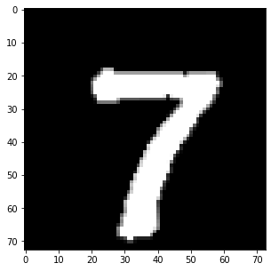

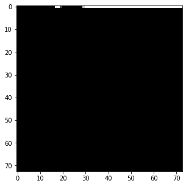

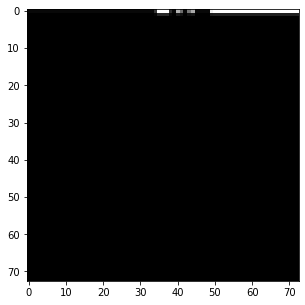

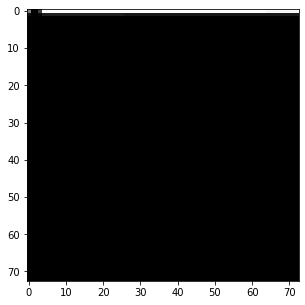

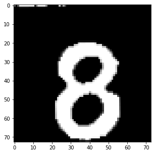

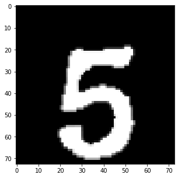

```python
# print the first row of the puzzle as individual sections (with cleaning)
for i in range(1):

    for j in range(9):

        digit_section = grid_slice(cropped_puzzle, i, j, width)
        digit_section = digit_section.astype(float)/255
        digit_section = remove_extra(digit_section)

        plt.figure(figsize = (5, 5))
        plt.imshow(digit_section, cmap = "gray")
```

Great, our image looks a lot cleaner now!

We can now move on to digit classification using a neural network.

```python
import cv2
import torch
from src.model_selection import get_model
from src.classifier_model import smart_classify

net = get_model("resnet50")
path_to_model = "resnet50_mnist.pth"

net.load_state_dict(torch.load(path_to_model))

net = net.to(device = "cpu")
```

```python
digit_list = list()

for i in range(9):

    for j in range(9):

        digit_section = grid_slice(cropped_puzzle, i, j, width)
        digit_section = digit_section.astype(float)/255
        digit_section = remove_extra(digit_section)

        resized_digit = cv2.resize(digit_section, (28, 28), interpolation = cv2.INTER_AREA)

        digit_list.append(smart_classify(resized_digit, net, conf_threshold = 0.9))
```

```python
print(digit_list)
```

[output not shown]

### Step Three: Solve and Output Puzzle

Since this topic is pretty widely covered, I opted to scour the internet for resources on sudoku solving algorithms rather than write my own. Surprisingly, this was some of the simplest code across the entire project! I won't list the code here, but it can be found in the repository for this project on my [Github](https://github.com/col-ms/sudoku-solver) if you'd like to take a look for yourself.

Let's get solving!

```python
# convert empty spaces to 0s for displaying puzzle grid
def prettify(digit):
    if digit == " ":
        return 0
    else:
        return int(digit)
```

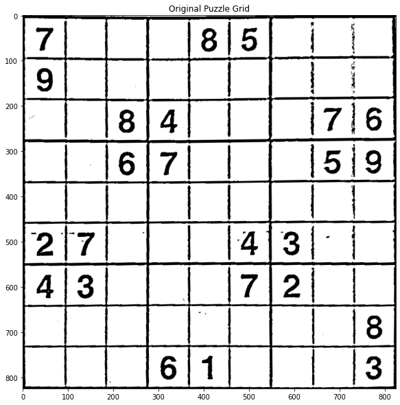

```python
from src.sudoku import find_empty_grid, solve_array, valid, print_board

plt.figure(figsize = (10, 10))
plt.imshow(255 - cropped_puzzle, cmap = "gray")
plt.title("Original Puzzle Grid")
plt.show()
```

```python
import numpy as np

digits_as_int = np.array([prettify(digit) for digit in digit_list])
digits_as_int = digits_as_int.reshape((9, 9))

digits_list = [list(digit) for digit in list(digits_as_int)]
```

```python
print("Original Board in Numerical Representation")
print("\n")
print_board(digits_list)
```

```
Original Board in Numerical Representation


7 . .  | . 8 .  | . . .
9 . .  | . . .  | . . .
. . 8  | 4 . .  | . 7 6
- - - - - - - - - - - - -
. . 6  | 7 . .  | . 5 9
. . .  | . . .  | . . .
. 7 .  | . . 4  | 3 . .
- - - - - - - - - - - - -
4 3 .  | . . 7  | 2 . .
. . .  | . . .  | . . 8
. . .  | 6 1 .  | . . 3
```

```python
# actual solving of the puzzle
completed_digit_list = list(digits_list)
solve_array(completed_digit_list)
```

```
True
```

```python
print("Completed Puzzle Board")
print("\n")
print_board(completed_digit_list)
```

```
Completed Puzzle Board


7 1 2  | 3 8 6  | 5 9 4
9 6 4  | 1 7 5  | 8 3 2
3 5 8  | 4 2 9  | 1 7 6
- - - - - - - - - - - - -
2 8 6  | 7 3 1  | 4 5 9
1 4 3  | 9 5 8  | 6 2 7
5 7 9  | 2 6 4  | 3 8 1
- - - - - - - - - - - - -
4 3 1  | 8 9 7  | 2 6 5
6 2 7  | 5 4 3  | 9 1 8
8 9 5  | 6 1 2  | 7 4 3
```

All of the source code for this project can be found on my [Github](https://github.com/col-ms/sudoku-solver).